```python
from IPython.display import HTML
```

# Introduction to Machine Learning

## [Machine learning versus statistics](https://www.nature.com/articles/nmeth.4642)

- "Statistics draws population inferences from a sample, and machine learning finds generalizable predictive patterns."
- "Statistical methods have a long-standing focus on **inference**, which is achieved through the creation and fitting of a project-specific probability model. The model allows us to compute a **quantitative measure of confidence that a discovered relationship describes a 'true' effect that is unlikely to result from noise.** Furthermore, if enough data are available, we can explicitly verify assumptions (e.g., equal variance) and refine the specified model, if needed."
- "By contrast, ML concentrates on **prediction by using general-purpose learning algorithms to find patterns in often rich and unwieldy data.** ML methods are particularly helpful when one is dealing with 'wide data', where the number of input variables exceeds the number of subjects, in contrast to 'long data', where the number of subjects is greater than that of input variables. ML makes **minimal assumptions about the data-generating systems**; they can be effective even when the data are gathered without a carefully controlled experimental design and in the presence of complicated nonlinear interactions."

Danilo Bzdok, Naomi Altman & Martin Krzywinski, Nature Methods volume 15, pages 233–234 (2018).

# Supervised Machine Learning

- classification (predicting classes)
- regression (predicting values)

## Classification

### Binary classification

- targert y: two classes (e.g., 0 or 1)

```python
from sklearn.metrics import confusion_matrix, precision_score, accuracy_score, f1_score
```

**model performance measurements: confusion matrix**

- **Accuray**

$$ accuracy = \dfrac{\rm TP + TN}{\rm Total (TP+TN+FP+FN)} $$

- **precision**

$$ precision = \dfrac{\rm TP}{\rm Predicted~Positive (TP+FP)} $$

- **recall/sensitivity/True Positive Rate(TPR)** $$ recall = \dfrac{\rm TP}{\rm Real~Positive (TP+FN)} $$
- **F1 score**

$$ F_1 = \dfrac{2}{\dfrac{1}{precision} + \dfrac{1}{recall}} = 2\times \dfrac{precision*recall}{precision + recall} $$

where

- TP: true positive = (predict positive| real positive)
- TN: true negative = (predict negative| real negative)
- FP: false positive = (predict positive| real negative)
- FN: false negative = (predict negative| real positive)

Note: For unbalanced dataset, the **recall** is more important than the precision and accuracy.

- Receiver operating characteristic (ROC) curve

True Positive Rate (recall/sensitivity) v.s. False Positive Rate (1 - Specificity)

where

- **False Positive Rate (FPR)**

$$ FPR = \dfrac{\rm FP}{\rm Real~Negative} = 1 - Specificity $$

- **Specificity/True Negative Rate (TNR)** $$ Specificity = \dfrac{\rm TN}{\rm Real~Negative} $$

The better algorithm gives a larger AUC (area under the curve) score.

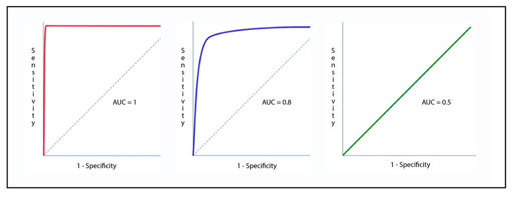

```python
import numpy as np
from IPython.display import Image
import matplotlib.pyplot as plt

Image("images/ROC_curves.jpg")
```

### Multiclass classification

- One versus the rest: still binary classification
- one versus one (pair)

## Regression

### Linear regression

- The linear regression computes the sum of weighted input features (plus a bias) and output this result.
- The prediction $\hat y^{(m)}$ for the $m$-th sample is parameterized as a linear function of the feature values $x^{(m)}_i$ (N features) of the $m$-th sample :

$$ \widehat y^{(m)} = h_\theta(\mathbf{X^{(m)}}) = \sum^N_{i=1} \theta_i x^{(m)}_i + \theta_0 = \mathbf{\theta}^T\cdot \mathbf{X}^{(m)} $$

where

1. $h_\theta(\mathbf{X})$ is a hypothesis (linear) function.
2. $\theta_i$ and $\theta_0$ are model parameters, $\theta_0$ is the bias term. Both are universal for all the samples.
3. vectorization of the relation: $$ \mathbf{\widehat y} =\left[\widehat y^{(1)}, \widehat y^{(2)}, \cdots, \widehat y^{(M)}\right] =\left[\theta_1, \theta_2, \cdots, \theta_N \right]\cdot \begin{bmatrix} x^{(1)}_1, & x^{(2)}_1, & \cdots, & x^{(M)}_1 \\ x^{(1)}_2, & x^{(2)}_2, & \cdots, & x^{(M)}_2 \\ \cdots, & \cdots, & \cdots, & \cdots \\ x^{(1)}_N, & x^{(2)}_N, & \cdots, &x^{(M)}_N \\ \end{bmatrix} =\mathbf{\theta}^T\cdot \mathbf{X} $$
- Mean-Square-Error (MSE): $$ MSE (\mathbf{\theta}) = \dfrac{1}{M} \sum^M_{m=1} (y^{(m)} - \widehat y^{(m)})^2. $$
- The model paramter $\mathbf{\theta}$ is determined by minization of the MSE and given by the solution of the following **Normal Equation** $$ \mathbf{\theta} = (\mathbf{X}^T\mathbf{X})^{-1}\mathbf{X}^T \mathbf{y} ={\cal X}^+ \mathbf{y}, $$ where
- ${\cal X}^+ \equiv (\mathbf{X}^T\mathbf{X})^{-1}\mathbf{X}^T$ is the so-called pseudo-inverse of $\mathbf{X}$, which can be calculated by

$$ {\cal X}^+ = np.linlg.pinv(X) $$

Note: using *SVD (pseudo-inverse)* method can avoid the singularity problem.

```python
m=100
X = 6*np.random.rand(m,1)
y = 3*X + 4 + np.random.rand(m,1) # plus noise
```

```python
X_plus_b = np.c_[np.ones((100,1)), X]  # add x0=1 to each instance
```

```python
theta_inv = np.linalg.inv(X_plus_b.T.dot(X_plus_b)).dot(X_plus_b.T).dot(y)
theta_inv
```

```
array([[4.50285414],
       [3.001809  ]])
```

```python
theta_svd = np.linalg.pinv(X_plus_b).dot(y)
```

```python
theta_svd
```

```
array([[4.50285414],
       [3.001809  ]])
```

- Regularization (Ridge/L2):
  1. Adding a term onto the cost function $J(\mathbf{\theta})$: $$ J(\mathbf{\theta}) = MSE (\mathbf{\theta}) + \dfrac{\alpha}{2} \mathbf{\theta}^T\mathbf{\theta}. $$
  2. The model paramter $\mathbf{\theta}$ is given by $$ \mathbf{\theta} = (\mathbf{X}^T\mathbf{X}+\alpha \mathbf{I})^{-1}\mathbf{X}^T \mathbf{y}, $$ where $\mathbf{I}$ is the Identity matrix, $\alpha$ contronls the size of the regularization term.

L2 Ridge regression is sensitive to the scale of features.

- Regularization (Lasso/L1):

$$ J(\mathbf{\theta}) = MSE (\mathbf{\theta}) + \alpha \sum^N_{i=0} \vert\theta_i\vert^2 $$

Features of L1 Lasso regression:

```
1. tends to elimilate the least important features.
2. automatically performs feature selections and outputs a sparese model.
3. Slope changes abruptly.
```

- Elastic Net (between L1 and L2):

$$ J(\mathbf{\theta}) = MSE (\mathbf{\theta}) + r \alpha\sum^N_{i=0} \vert\theta_i\vert^2 + \dfrac{1-r}{2}\alpha \mathbf{\theta}^T\mathbf{\theta} $$

Note: First try **Ridge**. If only a few features are important, then try **Elastic Net**.

```python
 np.random.randn
```

```
<function RandomState.randn>
```

```python
from sklearn.linear_model import LinearRegression, Ridge, Lasso, ElasticNet
```

```python
m=20
X = 6*np.random.rand(m,1)
y = 3*X + 4 + np.random.rand(m,1) # plus noise
```

```python
elastic_net = ElasticNet(alpha=0.1, l1_ratio=0.5)
elastic_net.fit(X,y)
y_pred = elastic_net.predict(X)
```

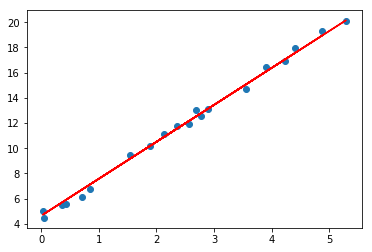

```python
plt.scatter(X,y.squeeze())
plt.plot(X,y_pred,'r')
```

```python
from scipy import stats
```

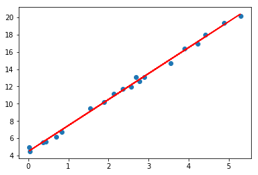

```python
slope, intercept, r_value, p_value, std_err = stats.linregress(X.reshape(1,-1), y.reshape(1,-1))
plt.plot(X, y, 'o', label='original data')
plt.plot(X, intercept + slope*X, 'r', label='fitted line')
```

```python
print("The r-value is {}".format(r_value))
```

```
The r-value is 0.9983031755104109
```

The statistic model also provides the quatitative measure of the confidence using the p-value, which is not the case for ML models.

*Note:* Pay attention to the shapes of the $X, y$:

- sklearn: dimension at least to be 2D
- scipy: dimension should be 1D

### Polynomial regression

The polynomial function of $X$ can be rewritten as a linear function of a new basis funcction $\phi(X)$:

$$ \begin{align} \widehat y &= \theta_0 + \theta_1 X + \theta_2 X^2 + \theta_3 X^3 + \cdots \nonumber\\ &= \theta_0 + \theta_1 \phi_1(X) + \theta_2 \phi_2(X) + \theta_3 \phi_3(X) + \cdots \nonumber\\ &= \mathbf{\theta}^T \cdot\mathbf{\phi(X)}, \end{align} $$ where $\phi_i(X)=1, X, X^2, X^3, \ldots$ for $i=1,2,3,\cdots$.

The basis function plays the role of scaling the features:

$$ X \to \phi(X) $$

```python
from sklearn.preprocessing import PolynomialFeatures
```

```python
poly_features = PolynomialFeatures(degree=2, include_bias=False)
X_poly = poly_features.fit_transform(X)
```

```python
elastic_net =ElasticNet(alpha=0.1, l1_ratio=0.5)
elastic_net.fit(X_poly, y)
elastic_net.intercept_, elastic_net.coef_
```

```
(array([5.0389554]), array([2.35301464, 0.11935787]))
```

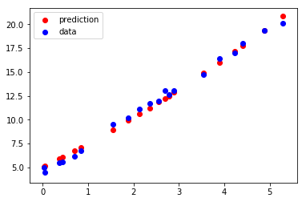

```python
plt.scatter(X,elastic_net.predict(X_poly),c='r',label='prediction')
plt.scatter(X,y.squeeze(),c='b',label='data')
plt.legend()
```

Note: Let's consider the case with $n$ features ($X_1, X_2, \cdots, X_n$) and $degree=d$. Then the number of new features

$$ {\rm No. of~} X^a_1X^b_2 \cdots X^c_n {\rm~terms}\sim \dfrac{(n+d)!}{d!n!} $$

increase factorially, which makes the computation heavy.

```python
style = " <style> div.highlight { background-color: #E0FFFF; border-color: #dFb5b4; border-left: 5px solid #dfb5b4; padding: 0.5em;}</style>"
HTML(style)
```

### Logistic regression

- to predict the probability $\widehat p$ that an instance belongs to a particular class.
  1. belongs to if $\widehat p>0.5$
  2. does not belong to if $\widehat p<0.5$
- A logistic regression computes **the sum of the weighted input features (plus a bias), and output the logistic of this result.**
- Cost function for a single training instance/sample

$$ C(\theta) = \begin{cases} -\log(\widehat p), {\rm if}~ y=1 ({\rm positive ~instance}),\\ -\log(1- \widehat p), {\rm if}~ y=0 ({\rm negative~ instance}),\\ \end{cases} $$ which can be rewritten as one expression $$ C^{(m)}(\theta) = -y^{(m)}\log(\widehat p^{(m)}) -(1-y^{(m)})\log(1- \widehat p^{(m)}). $$ Therefore, the cost function of the whole training set is

$$ J(\theta) = -\dfrac{1}{M} \sum^M_m \left[ y^{(m)}\log \widehat p^{(m)} +(1- y^{(m)})\log (1 - \widehat p^{(m)} )\right], $$

where

1. $y^{(m)}$ is the target value of the $m$-th instance/sample,
2. while $\widehat p^{(m)}$ is the **predicted** probability that the instance belonging to the class, given by $$ \widehat p^{(m)} = \sigma(\mathbf{\theta}^T \cdot \mathbf{X}^{(m)}) = \dfrac{1}{1+ e^{-\mathbf{\theta}^T \cdot \mathbf{X}^{(m)}}} =\dfrac{e^{\mathbf{\theta}^T \cdot \mathbf{X}^{(m)}}}{ e^{\mathbf{\theta}^T \cdot \mathbf{X}^{(m)}}+ e^0} $$

Note: the goal of training is to find the $\theta$ so that the model estimates high probability for positive instances and low probability for negative instances.

```
Text(0.5,0,'$\\widehat p^{(m)}$')
```

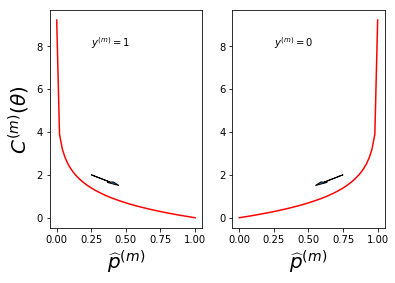

```python
plt.subplot(1,2,1)
x1=np.linspace(0.0001,0.9999)
plt.plot(x1,-np.log(x1),c='r')
plt.text(0.25,8,r'$y^{(m)}=1$')
plt.arrow(0.25,2,0.2,-0.5, head_length = 0.17, head_width = 0.05, length_includes_head = True)
plt.xlabel(r'$\widehat p^{(m)}$',fontsize=20)
plt.ylabel(r'$C^{(m)}(\theta)$',fontsize=20)

plt.subplot(1,2,2)
x0=np.linspace(0.0001,0.9999)
plt.plot(x0,-np.log(1-x0),c='r')
plt.text(0.25,8,r'$y^{(m)}=0$')
plt.arrow(0.75,2,-0.2,-0.5, head_length = 0.17, head_width = 0.05, length_includes_head = True)
plt.xlabel(r'$\widehat p^{(m)}$',fontsize=20)
```

Note: The cost function is convex ! The model parameter $\theta$ is determined by minimizing the cost function $C^{(m)}(\theta)$, which drives the $\widehat p^{(m)}$ towards the value of $y^{(m)}$.

```python
def sigmoid(t):
    return 1/(1+np.exp(-t))
```

```python
x = np.linspace(-50,50,200)
x = np.array(sorted(x))
```

```
Text(0.5,0,'$\\theta^T\\cdot \\mathbf{X}^{(m)}$')
```

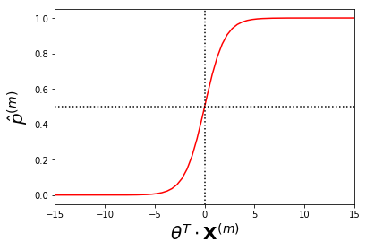

```python
plt.plot(x,sigmoid(x),c='r')
plt.xlim(-15,15)
plt.axhline(0.5,linestyle=':',c='k')
plt.axvline(0,linestyle=':',c='k')
plt.ylabel('$\hat p^{(m)}$', fontsize=20)
plt.xlabel(r'$\theta^T\cdot \mathbf{X}^{(m)}$', fontsize=20)
```

```python
from sklearn.linear_model import LogisticRegression
from sklearn import datasets
```

```python
iris = datasets.load_iris()
list(iris)
```

```
['data', 'target', 'target_names', 'DESCR', 'feature_names', 'filename']
```

```python
X= iris["data"][:,3:] # pental width
y=(iris["target"]==2).astype(np.int)
```

```python
log_reg = LogisticRegression()
log_reg.fit(X,y)
```

```
LogisticRegression(C=1.0, class_weight=None, dual=False, fit_intercept=True,
          intercept_scaling=1, max_iter=100, multi_class='warn',
          n_jobs=None, penalty='l2', random_state=None, solver='warn',
          tol=0.0001, verbose=0, warm_start=False)
```

```
Text(0.5,0,'Petal width (cm)')
```

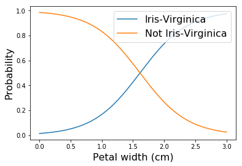

```python
X_new = np.linspace(0,3,1000).reshape(-1,1)
y_proba = log_reg.predict_proba(X_new)
plt.plot(X_new,y_proba[:,1],label='Iris-Virginica')
plt.plot(X_new,y_proba[:,0],label='Not Iris-Virginica')
plt.legend(loc=1,fontsize=16)
plt.ylabel('Probability', fontsize=16)
plt.xlabel('Petal width (cm)', fontsize=16)
```

### Softmax regression

- also called **Multinomial Logistic Regression**
- The softmax regression computes a score $s_k(\mathbf{X})$ for each class $k$, given an instance $\mathbf{X}$,

$$ s_k(\mathbf{X}) = \mathbf{\theta_{(k)}}^T\cdot \mathbf{X} $$

and then estimates the probability $\widehat p_k$ of each class by applying the *softmax function* to the scores

$$ \widehat p_k =\sigma(s(\mathbf{X}))_k = \dfrac{ e^{s_k(\mathbf{X}) }}{\sum^K_{k=1} e^{s_k(\theta)}}. $$

The denominator is *normalization factor*, $$ \sum^K_k\widehat p_k(\mathbf{X})=1. $$

1. $K$: number of the classkes
2. $s(\mathbf{X})$: a vector containing the scores of each class for the instance $\mathbf{X}$.
3. $\widehat p_k(\mathbf{X})$ is the predicted probability of the instance $\mathbf{X}$ belonging to the class $k$.
- The **softmax regression classifier** prediction is the the value of $k$, which maximizes the function $\sigma(s(\mathbf{X}))$ or equivalently the score $s_k(\mathbf{X})$:

$$ y = \underset{k}{argmax}~\sigma(s(\mathbf{X}))_k = \underset{k}{argmax} \left(\theta_{(k)}^T\cdot \mathbf{X}\right) $$

- **Cost function** is the *cross entropy* (for the case with $M$ instances/samples and $K$ classes):

$$ J(\Theta)= -\dfrac{1}{M} \sum^M_{m=1} \sum^K_{k=1}\left[ y^{(m)}_k\log \widehat p^{(m)}_k\right], $$

where **$y^{(m)}_k$ is either 1 or 0**, depending on whethe the $m$-th instance belongs to the class $k$ or not.

- Gradient of the cost function:

$$ \nabla_{\theta_{(k)}} J(\Theta) = \dfrac{1}{M} \sum^M_{m=1} \left(\widehat p^{(m)}_k - y^{(m)}_k\right) \mathbf{X}^{(m)}. $$

Note: In the deep-learing course by A. Ng, the symbol $a^{(m)}$ is introduced to replace $\widehat p^{(m)}$.

```python
style1 = " <style> div.warn { background-color: #fcf2f2; border-color: #dFb5b4; border-left: 5px solid #dfb5b4; padding: 0.5em;}</style>"
HTML(style1)
# #DCDCDC
```

Binary classification is a special case of softmax regression with $K=2$: $$y^{(m)}_{k=2}=1-y^{(m)}_{k=1}, \quad \widehat p^{(m)}_2 = 1 - \widehat p^{(m)}_1,$$

and the cost function is simplified as (set $y^{(m)}_{k=1}=y^{(m)}, \widehat p^{(m)}_1=\widehat p^{(m)}$)

$$ \begin{align} J(\Theta) &= -\dfrac{1}{M} \sum^M_m \sum^2_{k=1}\left[ y^{(m)}_k\log \widehat p^{(m)}_k\right] \nonumber\\ &= -\dfrac{1}{M} \sum^M_m \left[ y^{(m)}_1\log \widehat p^{(m)}_1 + y^{(m)}_2\log \widehat p^{(m)}_2\right]\nonumber\\ &= -\dfrac{1}{M} \sum^M_m \left[ y^{(m)} \log \widehat p^{(m)} + (1- y^{(m)})\log (1- \widehat p^{(m)})\right]. \end{align} $$

```python
X = iris["data"][:,(2,3)] # petal length and width
y = iris["target"]
y
```

```
array([0, 0, 0, 0, 0, 0, 0, 0, 0, 0, 0, 0, 0, 0, 0, 0, 0, 0, 0, 0, 0, 0,
       0, 0, 0, 0, 0, 0, 0, 0, 0, 0, 0, 0, 0, 0, 0, 0, 0, 0, 0, 0, 0, 0,
       0, 0, 0, 0, 0, 0, 1, 1, 1, 1, 1, 1, 1, 1, 1, 1, 1, 1, 1, 1, 1, 1,
       1, 1, 1, 1, 1, 1, 1, 1, 1, 1, 1, 1, 1, 1, 1, 1, 1, 1, 1, 1, 1, 1,
       1, 1, 1, 1, 1, 1, 1, 1, 1, 1, 1, 1, 2, 2, 2, 2, 2, 2, 2, 2, 2, 2,
       2, 2, 2, 2, 2, 2, 2, 2, 2, 2, 2, 2, 2, 2, 2, 2, 2, 2, 2, 2, 2, 2,
       2, 2, 2, 2, 2, 2, 2, 2, 2, 2, 2, 2, 2, 2, 2, 2, 2, 2])
```

```python
soft_reg = LogisticRegression(multi_class="multinomial",solver="lbfgs",C=10)
soft_reg.fit(X,y)
```

```
LogisticRegression(C=10, class_weight=None, dual=False, fit_intercept=True,
          intercept_scaling=1, max_iter=100, multi_class='multinomial',
          n_jobs=None, penalty='l2', random_state=None, solver='lbfgs',
          tol=0.0001, verbose=0, warm_start=False)
```

```python
X_test = [5,2]
soft_reg.predict([X_test]), soft_reg.predict_proba([X_test])
```

```
(array([2]), array([[6.38014896e-07, 5.74929995e-02, 9.42506362e-01]]))
```

```python
classes = ['class 0', 'class 1', 'class 2']
```

```python
prob = np.array(soft_reg.predict_proba([X_test])).squeeze()
```

```
Text(0,0.5,'Probability')
```

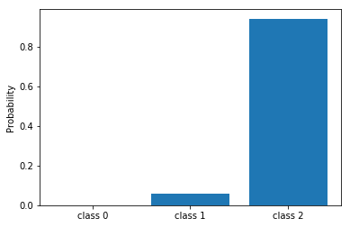

```python
plt.bar(classes,prob)
plt.ylabel("Probability")
```

## Support Vector Machines

- The instances located on the edge of the street are called *support vectors*.

#### Training object/cost function

$$ J(\Theta) = \dfrac{1}{2} \theta^T\theta $$ with the linear constraint $$ t^{(m)} (\theta^T \mathbf{X}^{(m)}+b) \ge 1 $$

where $t^{(m)}$ is 1 for the positive instance (corresponding to $y^{(m)}=1$) and -1 for the negative instance (corresponding to $y^{(m)}=0$).

One can use the following cost function to take care of the constraint term

$$ J(\Theta, b) = \dfrac{1}{2} \theta^T\theta + C\sum^M_{m=1} max\left(0, 1- t^{(m)} (\theta^T \mathbf{X}^{(m)}+b)\right). $$

1. The first term is pushing the model to have a smallest value of $\theta$, namely, the largest margin/street.
2. The second term (called *Hinge Loss*) is minimizing the marginal violations (proportional to the distance to the correct side of the street) as small/few as possible.

#### Decision function

- Linear SVM classification

$$ \widehat y = \begin{cases} 0, & \quad \theta^T \mathbf{X}+b<0\\ 1, & \quad \theta^T \mathbf{X}+b >0 \end{cases} $$

### SVM Classification

#### Soft marginal classification

- *hard margin classification*: require all the instances being off the street. This classification is sensitive to the outliers.
- *soft margin classification*: find a good balance between keeping the street as large as possible and limiting the margin violation (numbers of instances in the middle of the street).

#### Nonlinear SVM classifications

- add *polynomial features* by using *polynomial kernel*.

For the degree of 2 polynomial mapping: $$ \phi(\mathbf{X}) =\phi\begin{pmatrix} x_1 \\ x_2 \end{pmatrix} =\begin{pmatrix} x^2_1 \\ \sqrt{2}x_1x_2\\ x^2_2 \end{pmatrix} $$

and the dot product

$$ \phi(\mathbf{X})^T\phi(\mathbf{Y}) =\begin{pmatrix} x^2_1 \\ \sqrt{2}x_1x_2\\ x^2_2 \end{pmatrix}^T \begin{pmatrix} y^2_1 \\ \sqrt{2}y_1y_2\\ y^2_2 \end{pmatrix} =(\mathbf{X}^T\mathbf{Y})^2 \equiv K(\mathbf{X},\mathbf{Y}), $$ where $K(\mathbf{X},\mathbf{Y})$ called a $2$nd-degree polynomial kernel.

- add *Similarity features* by using *Gaussian RBF kernel*

For a given landmark $\mathbf{\ell}$, one can map the feature $\mathbf{X}$ to a new feature using a Gaussian function which measures the similarity between the feature $\mathbf{X}$ and the landmark:

$$ K(\mathbf{X}, \mathbf{\ell}) \equiv \phi_\gamma(\mathbf{X}, \mathbf{\ell}) = \exp(-\gamma \vert\vert \mathbf{X} - \mathbf{\ell}\vert\vert^2) $$

- The landmark $\mathbf{\ell}$ is usually taken at the location of each and every instance in the dataset.

Therefore, if there are $m$ instance with $n$ features in the dataset, these $n$ features introduce $n^2$ Gaussian functions, thus $n^2$ new features. The time complexcity is increased

$$ O(m\times n) \to O(m\times n^2) $$

```python
X = iris["data"][:, (2,3)]
y = (iris["target"]==2).astype(np.float64)
```

```python
def plot_decision_boundary(model, X, y):

    # Set min and max values and give it some padding
    x_min, x_max = X[:,0].min() - 1, X[:,0].max() + 1   # x1
    y_min, y_max = X[:,1].min() - 1, X[:,1].max() + 1   # x2
    h = 0.01
    # Generate a grid of points with distance h between them
    xx, yy = np.meshgrid(np.arange(x_min, x_max, h), np.arange(y_min, y_max, h))

    # Predict the function value for the whole grid
    Z = model(np.c_[xx.ravel(), yy.ravel()])  # numpy.ravel() == numpy.reshape(-1); np.c_: Stack 1-D arrays as columns into a 2-D array
    Z = Z.reshape(xx.shape)

    # Plot the contour and training examples
    plt.contourf(xx, yy, Z, cmap='binary')
    plt.ylabel('x2')
    plt.xlabel('x1')
    plt.scatter(X[:,0], X[:,1], c=y.ravel(), cmap=plt.cm.Spectral)
```

```python
from sklearn.pipeline import Pipeline
from sklearn.svm import LinearSVC,SVC
from sklearn.preprocessing import PolynomialFeatures, StandardScaler

polynomial_svm_clf = Pipeline(
[("poly_features", PolynomialFeatures(degree=3)),
("scaler",StandardScaler()),
("svm_clf",LinearSVC(C=10,loss="hinge"))
])

polynomial_svm_clf_poly3 = Pipeline(
[("poly_features", PolynomialFeatures(degree=3)),
("scaler",StandardScaler()),
("svm_clf",SVC(kernel="poly", degree=3,coef0=1,C=5))
])

polynomial_svm_clf_rbf = Pipeline(
[("poly_features", PolynomialFeatures(degree=3)),
("scaler",StandardScaler()),
("svm_clf",SVC(kernel="rbf", degree=3,coef0=1,C=5))
])

polynomial_svm_clf.fit(X,y)
```

```
Pipeline(memory=None,
     steps=[('poly_features', PolynomialFeatures(degree=3, include_bias=True, interaction_only=False)), ('scaler', StandardScaler(copy=True, with_mean=True, with_std=True)), ('svm_clf', LinearSVC(C=10, class_weight=None, dual=True, fit_intercept=True,
     intercept_scaling=1, loss='hinge', max_iter=1000, multi_class='ovr',
     penalty='l2', random_state=None, tol=0.0001, verbose=0))])
```

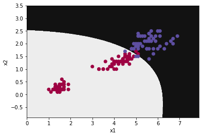

```python
X_test = np.array([5,2]).reshape(1,-1)
polynomial_svm_clf.predict(X_test)
plot_decision_boundary(lambda x: polynomial_svm_clf.predict(x), X, y)
```

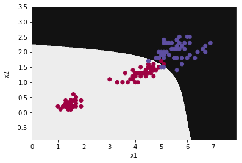

```python
polynomial_svm_clf_poly3.fit(X,y)
plot_decision_boundary(lambda x: polynomial_svm_clf_poly3.predict(x), X, y)
```

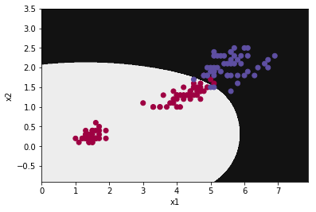

```python
polynomial_svm_clf_rbf.fit(X,y)
plot_decision_boundary(lambda x: polynomial_svm_clf_rbf.predict(x), X, y)
```

### SVM Regression

- for both linear and non-linear regressions
- the street width is controled by the parameter $\epsilon$

```python
X = np.random.rand(100,1)*5
y = X**3 + 10*X**2 + X + 4
```

```python
X_plus_b = np.c_[np.ones((100,1)), X]  # add x0=1 to each instance
```

```python
from sklearn.svm import SVR
from sklearn.metrics import mean_squared_error
```

```python
svm_poly_reg = SVR(kernel="poly", degree=3, C=100, epsilon=0.1)
svm_poly_reg.fit(X_plus_b,y)
```

```
SVR(C=100, cache_size=200, coef0=0.0, degree=3, epsilon=0.1,
  gamma='auto_deprecated', kernel='poly', max_iter=-1, shrinking=True,
  tol=0.001, verbose=False)
```

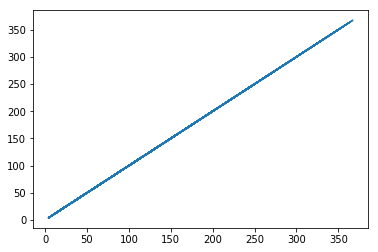

```python
y_pred = svm_poly_reg.predict(X_plus_b)
plt.plot(y,y_pred)
```

```python
mean_squared_error(y,y_pred)
```

```
0.004644341964169357
```

## Decision Trees

- Classification
- Regression

```python
X=iris["data"][:,2:]
y=iris["target"]
```

```python
from sklearn.tree import DecisionTreeClassifier
```

```python
tree_clf = DecisionTreeClassifier()
tree_clf.fit(X,y)
```

```
DecisionTreeClassifier(class_weight=None, criterion='gini', max_depth=None,
            max_features=None, max_leaf_nodes=None,
            min_impurity_decrease=0.0, min_impurity_split=None,
            min_samples_leaf=1, min_samples_split=2,
            min_weight_fraction_leaf=0.0, presort=False, random_state=None,
            splitter='best')
```

```python
from sklearn.tree import export_graphviz
export_graphviz(tree_clf,
               out_file=("iris_tree.dot"),
               feature_names=iris.feature_names[2:],
               class_names=iris.target_names,
               rounded=True,
               filled=True)
```

```python
! dot -Tpng iris_tree.dot -o iris_tree.png
```

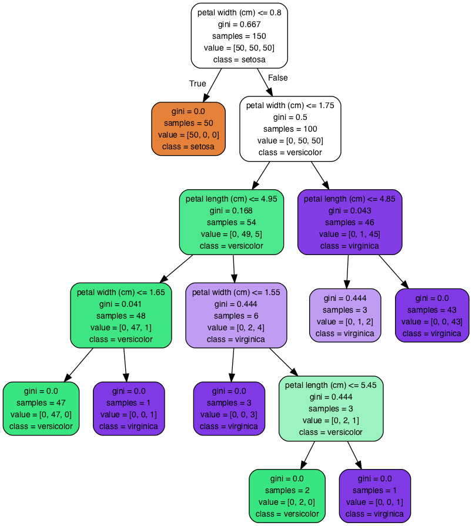

```python
Image("iris_tree.png")
```

- Gini Impurity

$$ G_{i} = 1 - \sum^K_{k=1} p^2_{i,k} $$ where $p_{i,k}$ is the ratio of the class $k$ instances among the training instances in the $i$-th node:

For example: for the right-child node in the second layer (depth-1), samples = 100, value =[0,50,50]. The Gini score is given by

$$ G_i = 1 - (0/100)^2 - (50/100)^2 - (50/100)^2 = 0.5 $$

- Training algorithm and cost function for classification:

The Classification and Regression Tree (CART) algorithm trains Decision Tree by splitting the trainsing set in two subsets using a single feature $k$ and a threshold $t_k$. The paramters $k$ and $t_k$ are chosen in such a way that it preoduces the purest subsets, weighted by their size, $$ J(k, t_k) = \dfrac{M_{\rm left}}{M} G_{\rm left} + \dfrac{M_{\rm right}}{M} G_{\rm right} $$ where $M_{\rm left/right}$ is the number of instances in the left/right node/subset.

Alternative, one can also use the **entropy** impurity measure:

$$ H_i = -\sum^K_{k=1, p_{i,k}\neq 0} p_{i, k} \log_2(p_{i,k}) $$

*Decision Tree versus Linear models:*

1. Decision Tree does not assume that the data is linear.
2. belongs to **non-parameteric** model.
3. most likely overfit the data
4. use **max_depth, max_leaf_nodes and mini_samples_leaf** to regularize the model.
5. Simple to understand and interpret.
6. Sensitive to a small variations in the training data.

   Linear models belong to *parametric model*. The model parameters are predetermined, which reduces the risk of overfitting to some extend.
- Cost function for regression:

$$ J(k, t_k) = \dfrac{M_{\rm left}}{M} {\rm MSE}_{\rm left} + \dfrac{M_{\rm right}}{M} {\rm MSE}_{\rm right} $$ where

$$ {\rm MSE}_{\rm node} = \sum_{m\in node} (\widehat y_{node} - y^{(m)})^2, \quad \widehat y_{node}=\dfrac{1}{M_{node}} \sum_{m \in node} y^{(m)} $$

## Ensenmble and Random Forest

### Voting

- Train a few classfiers (based on **different algorithms**) trainand aggregate the predictions of each classifier and **predict the class that gets the most votes**.
- The ensemble can do much **better than each classifer, provided that the classifiers are independent**.

```python
from sklearn.ensemble import RandomForestClassifier, VotingClassifier
from sklearn.linear_model import LogisticRegression
from sklearn.svm import SVC
```

```python
log_clf = LogisticRegression()
rnd_clf = RandomForestClassifier()
svm_clf = SVC()

voting_clf = VotingClassifier(
estimators=[
    ('lr',log_clf),
    ('rf',rnd_clf),
    ('svc',svm_clf)],
voting = 'hard')

voting_clf.fit(X,y)
```

```
VotingClassifier(estimators=[('lr', LogisticRegression(C=1.0, class_weight=None, dual=False, fit_intercept=True,
          intercept_scaling=1, max_iter=100, multi_class='warn',
          n_jobs=None, penalty='l2', random_state=None, solver='warn',
          tol=0.0001, verbose=0, warm_start=False)), ('rf', RandomFo...f', max_iter=-1, probability=False, random_state=None,
  shrinking=True, tol=0.001, verbose=False))],
         flatten_transform=None, n_jobs=None, voting='hard', weights=None)
```

```python
from sklearn.metrics import accuracy_score

for clf in (log_clf, rnd_clf, svm_clf, voting_clf):
    clf.fit(X,y)
    y_pred = clf.predict(X)
    print(clf.__class__.__name__,accuracy_score(y,y_pred))
```

```
LogisticRegression 0.8733333333333333
RandomForestClassifier 0.9933333333333333
SVC 0.9666666666666667
VotingClassifier 0.9733333333333334
```

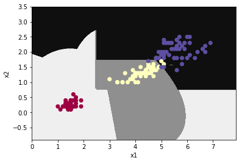

```python
plot_decision_boundary(lambda x:  clf.predict(x), X, y)
```

### Bagging and Pasting

- Use the *same training algorithm* for every predictor, but to train on **different random subsets of the training set**.
- **Bagging**: sampling is performed with replacement (bootstrap=True)
- **Pasting**: sampling is performed without replacement
- Aggregate the predictions of all predictors, and take either the most frequent prediction for classification or average for regresion.
- Aggregation reduces both bias and variance. Generally, the ensemble has a similar bias, but a lower variance than a sinple predictor.
- Bagging ends up with a little bit higher bias than Pasting.

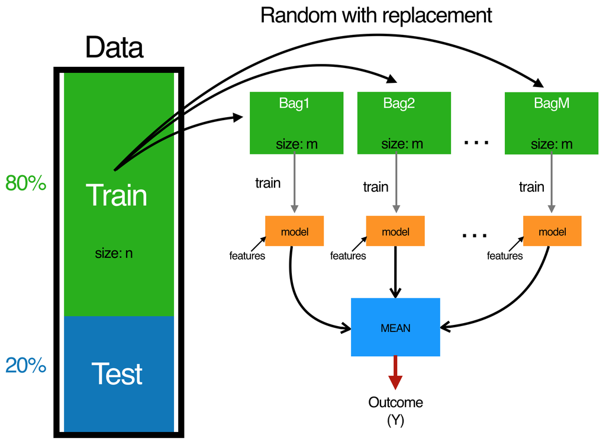

```python
Image("images/bagging.png", width=800)
```

```python
X=iris["data"][:,2:]
y=iris["target"]
```

```python
X.shape,y.shape
```

```
((150, 2), (150,))
```

```python
from sklearn.ensemble import BaggingClassifier
from sklearn.tree import DecisionTreeClassifier

tree_clf = DecisionTreeClassifier()
tree_clf.fit(X,y)

bag_clf = BaggingClassifier(
        DecisionTreeClassifier(),
        n_estimators=500,
        max_samples=100,
        bootstrap=True,
        n_jobs=-1,
        oob_score=True)

bag_clf.fit(X,y)
y_pred = bag_clf.predict(X)
```

```
0.9666666666666667
```

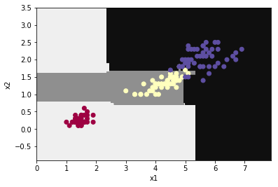

```python
plot_decision_boundary(lambda x:  bag_clf.predict(x), X, y)
bag_clf.oob_score_
```

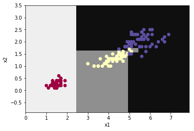

```python
plot_decision_boundary(lambda x:  tree_clf.predict(x), X, y)
```

### Random Forest

- An ensemble of Decision Trees
- Trained via the Bagging method
- provide a measure on feature importance

```python
from sklearn.ensemble import RandomForestClassifier
```

```python
rnd_clf = RandomForestClassifier(n_estimators=500,max_leaf_nodes=16,n_jobs=-1)
rnd_clf.fit(X,y)
```

```
RandomForestClassifier(bootstrap=True, class_weight=None, criterion='gini',
            max_depth=None, max_features='auto', max_leaf_nodes=16,
            min_impurity_decrease=0.0, min_impurity_split=None,
            min_samples_leaf=1, min_samples_split=2,
            min_weight_fraction_leaf=0.0, n_estimators=500, n_jobs=-1,
            oob_score=False, random_state=None, verbose=0,
            warm_start=False)
```

```python
for name,score in zip(iris['feature_names'],rnd_clf.feature_importances_):
    print(name,score)
```

```
sepal length (cm) 0.48803363807696976
sepal width (cm) 0.5119663619230304
```

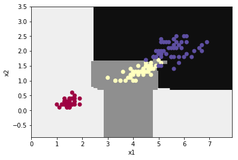

```python
plot_decision_boundary(lambda x:  rnd_clf.predict(x), X, y)
```

*Comparison with Bagging based on DecisionTree*

```python
bag_clf = BaggingClassifier(
    DecisionTreeClassifier(
            splitter='random',
            max_leaf_nodes=16),
    n_estimators=500,
    max_samples=1.0,
    bootstrap=True,
    n_jobs=-1)
```

```python
bag_clf.fit(X,y)
```

```
BaggingClassifier(base_estimator=DecisionTreeClassifier(class_weight=None, criterion='gini', max_depth=None,
            max_features=None, max_leaf_nodes=16,
            min_impurity_decrease=0.0, min_impurity_split=None,
            min_samples_leaf=1, min_samples_split=2,
            min_weight_fraction_leaf=0.0, presort=False, random_state=None,
            splitter='random'),
         bootstrap=True, bootstrap_features=False, max_features=1.0,
         max_samples=1.0, n_estimators=500, n_jobs=-1, oob_score=False,
         random_state=None, verbose=0, warm_start=False)
```

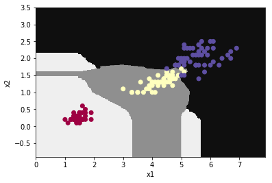

```python
plot_decision_boundary(lambda x:  bag_clf.predict(x), X, y)
```

### Boosting

- Train predictors sequentially, each trying to correct
- Ensemble method that can comnine several weaker learners into a strong learner

## Training Algorithms: Gradient descent

# Unsupervised Machine Learning

# Reference

- Hands on Machine Learning with Scikit-Learn and Tensorflow, by Aurélien Géron